# Presidential Election 1999

# Structure of Document

Data extraction begins from page five of the document. Each page from here has a table representing each district. All tables follow the similar format.

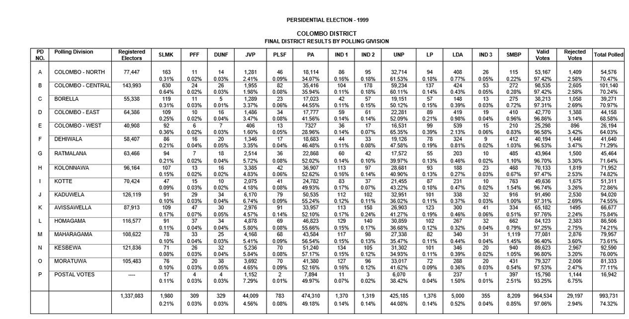

# Process of Extraction

Each table has been extracted separately without any issues. Three inputs are used the first is page number, second is number of rows in the table (except heading). There is one special case which is for Gampaha district.

```r
# load the pdf file
SL_PE_1999<-pdf_text("PresidentialElections1999.pdf")

# source the function
source("Extract1999.R")

# creating initial dataset Election1999
Election1999<-NULL

# extracting Colombo district table
Election1999[[1]]<-Extract_table1999(5,17)

# extracting Gamapaha district table
Election1999[[2]]<-Extract_table1999(6,15,GA=TRUE)

# extracting Kalutara district table
Election1999[[3]]<-Extract_table1999(7,10)

# extracting Mahanuwara district table
Election1999[[4]]<-Extract_table1999(8,15)

# extracting Matale district table
Election1999[[5]]<-Extract_table1999(9,6)

# extracting Nuwara-Eliya district table
Election1999[[6]]<-Extract_table1999(10,6)

# extracting Galle district table
Election1999[[7]]<-Extract_table1999(11,12)

# extracting Matara district table
Election1999[[8]]<-Extract_table1999(12,9)

# extracting Hambantota district table
Election1999[[9]]<-Extract_table1999(13,6)

# extracting Jaffna district table
Election1999[[10]]<-Extract_table1999(14,13)

# extracting Vanni district table
Election1999[[11]]<-Extract_table1999(15,5)

# extracting Batticaloa district table
Election1999[[12]]<-Extract_table1999(16,5)

# extracting Trincomalee district table
Election1999[[13]]<-Extract_table1999(17,5)

# extracting Digamadulla district table
Election1999[[14]]<-Extract_table1999(18,6)

# extracting Kurunegala district table
Election1999[[15]]<-Extract_table1999(19,16)

# extracting puttalam district table
Election1999[[16]]<-Extract_table1999(20,7)

# extracting Anuradhapura district table
Election1999[[17]]<-Extract_table1999(21,9)

# extracting Polonnaruwa district table
Election1999[[18]]<-Extract_table1999(22,5)

# extracting Badulla district table
Election1999[[19]]<-Extract_table1999(23,11)

# extracting Moneragala district table
Election1999[[20]]<-Extract_table1999(24,5)

# extracting Ratnapura district table
Election1999[[21]]<-Extract_table1999(25,10)

# extracting Kegalle district table
Election1999[[22]]<-Extract_table1999(26,11)

# final data set
Election1999<-do.call("rbind",Election1999)
```

# Validating Data Extracted

There is a summary for election results yet both way tallying is compared between the extracted data. Also both way tallying is used to clarify the summary as well. Both Way Tallying means summation of all district final results is equal to summation of all electorates final results.

## Checking for Registered Electors.

No issues here.

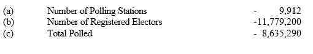

```r
# Extracting only Final District Results of
# Number of Registered Electors
# and then adding all the votes
ElecFinal1999<-subset(Election1999,Electorate=="FINAL DISTRICT RESULTS"
                      & ColNames=="Registered Electors")
# added votes will be cross checked with the pdf document
ElecFinal1999[,sum(Votes),by="ColNames"]
```

```
##               ColNames       V1
## 1: Registered Electors 11779200
```

```r
# Extracting except Final District Results of
# Number of Registered Electors
# and then adding all the votes
ElecFinal1999<-subset(Election1999,Electorate!="FINAL DISTRICT RESULTS"
                      & Electorate!="POSTAL VOTES"
                      & ColNames=="Registered Electors")
# added votes will be cross checked with the pdf document
ElecFinal1999[,sum(Votes),by="ColNames"]
```

```
##               ColNames       V1
## 1: Registered Electors 11779200
```

## Checking for Total Polled

No issues here.

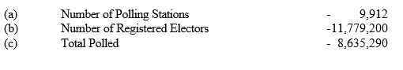

```r
# Extracting only Final District Results of
# Total Polled
# and then adding all the votes
ElecFinal1999<-subset(Election1999,Electorate=="FINAL DISTRICT RESULTS"
                      & ColNames=="Total Polled")
# added votes will be cross checked with the pdf document
ElecFinal1999[,sum(Votes),by="ColNames"]
```

```
##        ColNames      V1
## 1: Total Polled 8635290
```

```r
# Extracting except Final District Results of
# Total Polled
# and then adding all the votes
ElecFinal1999<-subset(Election1999,Electorate!="FINAL DISTRICT RESULTS"
                      & ColNames=="Total Polled")
# added votes will be cross checked with the pdf document
ElecFinal1999[,sum(Votes),by="ColNames"]
```

```
##        ColNames      V1
## 1: Total Polled 8635290
```

## Checking for Rejected Votes

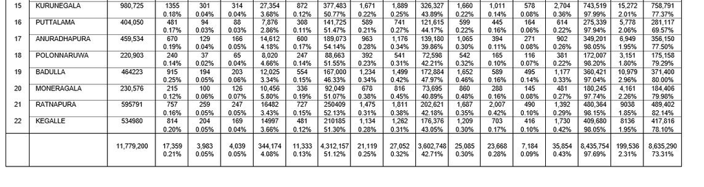

```r
# Extracting only Final District Results of
# Total Polled
# and then adding all the votes
ElecFinal1999<-subset(Election1999,Electorate=="FINAL DISTRICT RESULTS"
                      & ColNames=="Rejected Votes")
# added votes will be cross checked with the pdf document
ElecFinal1999[,sum(Votes),by="ColNames"]
```

```
##          ColNames     V1
## 1: Rejected Votes 199537
```

```r
# Extracting except Final District Results of
# Total Polled
# and then adding all the votes
ElecFinal1999<-subset(Election1999,Electorate!="FINAL DISTRICT RESULTS"
                      & ColNames=="Rejected Votes")
# added votes will be cross checked with the pdf document
ElecFinal1999[,sum(Votes),by="ColNames"]
```

```
##          ColNames     V1
## 1: Rejected Votes 199536
```

### Jaffna District

The tallied rejected votes of Jaffna district is 5981 but here it is misprinted as 5982, which has lead to that one vote increase. So the final total rejected vote count is 199536.

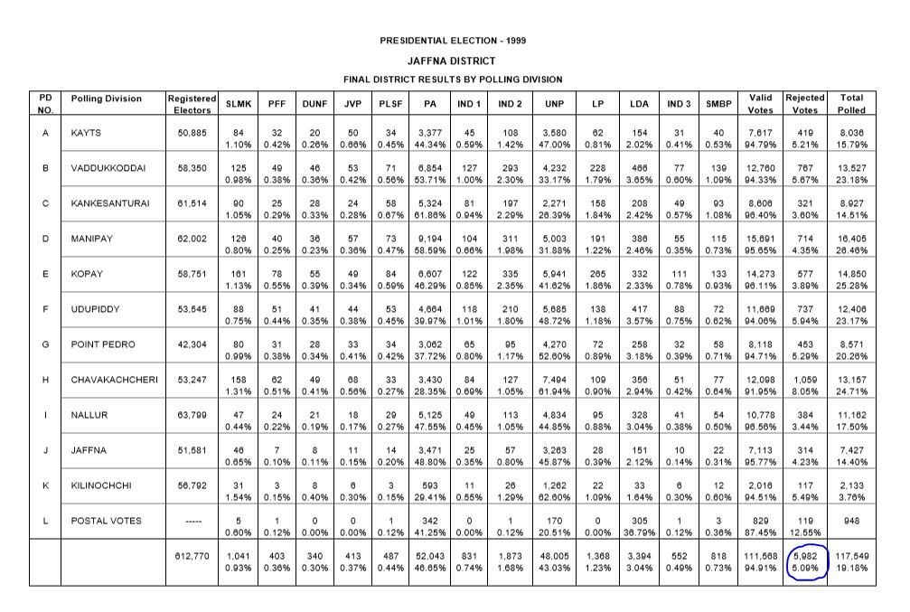

```r
ElecFinal1999<-subset(Election1999,Electorate!="FINAL DISTRICT RESULTS"
                      & District=="JAFFNA"
                      & ColNames=="Rejected Votes")

ElecFinal1999[,sum(Votes),by="ColNames"]
```

```
##          ColNames   V1
## 1: Rejected Votes 5981
```

## Checking for Valid Votes

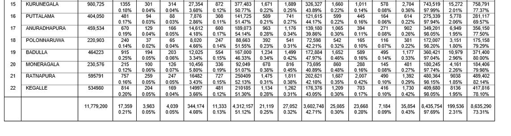

```r
# Extracting only Final District Results of
# Valid Votes
# and then adding all the votes
ElecFinal1999<-subset(Election1999,Electorate=="FINAL DISTRICT RESULTS"
                      & ColNames=="Valid Votes")
# added votes will be cross checked with the pdf document
ElecFinal1999[,sum(Votes),by="ColNames"]
```

```
##       ColNames      V1
## 1: Valid Votes 8435762
```

```r
# Extracting except Final District Results of
# Valid Votes
# and then adding all the votes
ElecFinal1999<-subset(Election1999,Electorate!="FINAL DISTRICT RESULTS"
                      & ColNames=="Valid Votes")
# added votes will be cross checked with the pdf document
ElecFinal1999[,sum(Votes),by="ColNames"]
```

```
##       ColNames      V1
## 1: Valid Votes 8435754
```

### Anuradhapura District

Total valid votes for Anuradhapura district is 349201 but in the tally section they have mistakenly printed as 349209.

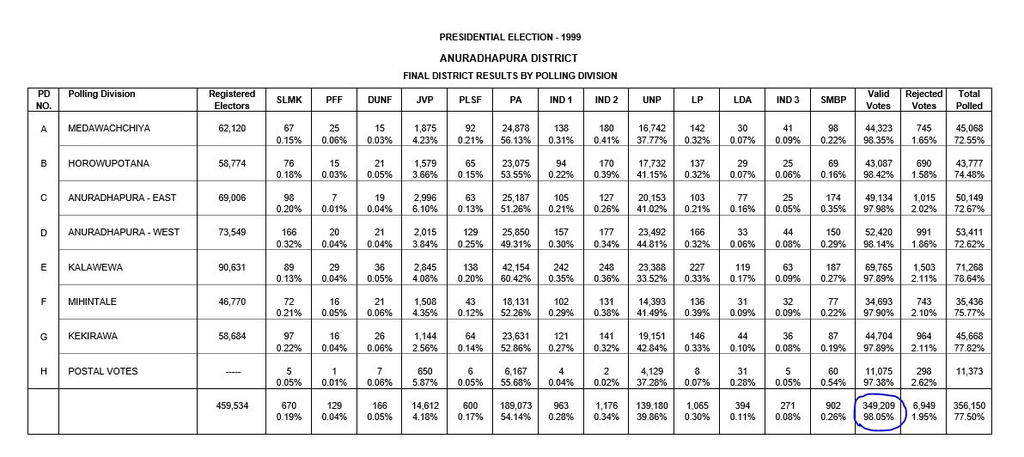

```r
ElecFinal1999<-subset(Election1999,Electorate!="FINAL DISTRICT RESULTS"
                      & District=="ANURADHAPURA"
                      & ColNames=="Valid Votes")
# added votes will be cross checked with the pdf document
ElecFinal1999[,sum(Votes),by="ColNames"]
```

```
##       ColNames     V1
## 1: Valid Votes 349201
```

## Comparing final tally votes of Mrs. Chandrika Bandaranaike Kumarathunga

No issues here.

```r
# Extracting only Final District Results of
# Mrs. Chandrika Bandaranaike Kumarathunga
# and then adding all the votes
ElecFinal1999<-subset(Election1999,Electorate=="FINAL DISTRICT RESULTS"
                      & ColNames=="PA")
# added votes will be cross checked with the pdf document
ElecFinal1999[,sum(Votes),by="ColNames"]
```

```
##    ColNames      V1
## 1:       PA 4312157
```

```r
# Extracting except Final District Results of
# Mrs. Chandrika Bandaranaike Kumarathunga
# and then adding all the votes
ElecFinal1999<-subset(Election1999,Electorate!="FINAL DISTRICT RESULTS"
                      & ColNames=="PA")
# added votes will be cross checked with the pdf document
ElecFinal1999[,sum(Votes),by="ColNames"]
```

```
##    ColNames      V1
## 1:       PA 4312157
```

## Comparing final tally votes of Mr. Ranil Wickremasinghe

No issues here.

```r
# Extracting only Final District Results of
#  Mr. Ranil Wickremasinghe
# and then adding all the votes
ElecFinal1999<-subset(Election1999,Electorate=="FINAL DISTRICT RESULTS"
                      & ColNames=="UNP")
# added votes will be cross checked with the pdf document
ElecFinal1999[,sum(Votes),by="ColNames"]
```

```
##    ColNames      V1
## 1:      UNP 3602748
```

```r
# Extracting except Final District Results of
#  Mr. Ranil Wickremasinghe
# and then adding all the votes
ElecFinal1999<-subset(Election1999,Electorate!="FINAL DISTRICT RESULTS"
                      & ColNames=="UNP")
# added votes will be cross checked with the pdf document
ElecFinal1999[,sum(Votes),by="ColNames"]
```

```
##    ColNames      V1
## 1:      UNP 3602748
```

## Comparing final tally votes of Mr. M. D. Nandana Gunathilaka

```r
# Extracting only Final District Results of
#  Mr.  M. D. Nandana Gunathilaka
# and then adding all the votes
ElecFinal1999<-subset(Election1999,Electorate=="FINAL DISTRICT RESULTS"
                      & ColNames=="JVP")
# added votes will be cross checked with the pdf document
ElecFinal1999[,sum(Votes),by="ColNames"]
```

```
##    ColNames     V1
## 1:      JVP 344173
```

```r
# Extracting except Final District Results of
#  Mr.  M. D. Nandana Gunathilaka
# and then adding all the votes
ElecFinal1999<-subset(Election1999,Electorate!="FINAL DISTRICT RESULTS"
                      & ColNames=="JVP")
# added votes will be cross checked with the pdf document
ElecFinal1999[,sum(Votes),by="ColNames"]
```

```
##    ColNames     V1
## 1:      JVP 344173
```

## Comparing final tally votes of Mr. Harischandra Wijayatunga

No issues here.

```r
# Extracting only Final District Results of
# Mr.  Harischandra Wijayatunga
# and then adding all the votes
ElecFinal1999<-subset(Election1999,Electorate=="FINAL DISTRICT RESULTS"
                      & ColNames=="SMBP")
# added votes will be cross checked with the pdf document
ElecFinal1999[,sum(Votes),by="ColNames"]
```

```
##    ColNames    V1
## 1:     SMBP 35854
```

```r
# Extracting except Final District Results of
# Mr.  Harischandra Wijayatunga
# and then adding all the votes
ElecFinal1999<-subset(Election1999,Electorate!="FINAL DISTRICT RESULTS"
                      & ColNames=="SMBP")
# added votes will be cross checked with the pdf document
ElecFinal1999[,sum(Votes),by="ColNames"]
```

```
##    ColNames    V1
## 1:     SMBP 35854
```

## Comparing final tally votes of Mr. Tennyson Edirisuriya

No issues here.

```r
# Extracting only Final District Results of
# Mr.  Tennyson Edirisuriya
# and then adding all the votes
ElecFinal1999<-subset(Election1999,Electorate=="FINAL DISTRICT RESULTS"
                      & ColNames=="IND1")
# added votes will be cross checked with the pdf document
ElecFinal1999[,sum(Votes),by="ColNames"]
```

```
##    ColNames    V1
## 1:     IND1 21119
```

```r
# Extracting except Final District Results of
# Mr.  Tennyson Edirisuriya
# and then adding all the votes
ElecFinal1999<-subset(Election1999,Electorate!="FINAL DISTRICT RESULTS"
                      & ColNames=="IND1")
# added votes will be cross checked with the pdf document
ElecFinal1999[,sum(Votes),by="ColNames"]
```

```
##    ColNames    V1
## 1:     IND1 21119
```

## Comparing final tally votes of Mr. W. V. M. Ranjith

No issues here.

```r
# Extracting only Final District Results of
# Mr. W. V. M. Ranjith
# and then adding all the votes
ElecFinal1999<-subset(Election1999,Electorate=="FINAL DISTRICT RESULTS"
                      & ColNames=="IND2")
# added votes will be cross checked with the pdf document
ElecFinal1999[,sum(Votes),by="ColNames"]
```

```
##    ColNames    V1
## 1:     IND2 27052
```

```r
# Extracting except Final District Results of
# Mr. W. V. M. Ranjith
# and then adding all the votes
ElecFinal1999<-subset(Election1999,Electorate!="FINAL DISTRICT RESULTS"
                      & ColNames=="IND2")
# added votes will be cross checked with the pdf document
ElecFinal1999[,sum(Votes),by="ColNames"]
```

```
##    ColNames    V1
## 1:     IND2 27052
```

## Comparing final tally votes of Mr. Rajiva Wijesinha

No issues here.

```r
# Extracting only Final District Results of
# Mr.  Rajiva Wijesinha
# and then adding all the votes
ElecFinal1999<-subset(Election1999,Electorate=="FINAL DISTRICT RESULTS"
                      & ColNames=="LP")
# added votes will be cross checked with the pdf document
ElecFinal1999[,sum(Votes),by="ColNames"]
```

```
##    ColNames    V1
## 1:       LP 25085
```

```r
# Extracting except Final District Results of
# Mr.  Rajiva Wijesinha
# and then adding all the votes
ElecFinal1999<-subset(Election1999,Electorate!="FINAL DISTRICT RESULTS"
                      & ColNames=="LP")
# added votes will be cross checked with the pdf document
ElecFinal1999[,sum(Votes),by="ColNames"]
```

```
##    ColNames    V1
## 1:       LP 25085
```

## Comparing final tally votes of Mr. Vasudeva Nanyakkara

No issues here.

```r
# Extracting only Final District Results of
# Mr.  Vasudeva Nanyakkara
# and then adding all the votes
ElecFinal1999<-subset(Election1999,Electorate=="FINAL DISTRICT RESULTS"
                      & ColNames=="LDA")
# added votes will be cross checked with the pdf document
ElecFinal1999[,sum(Votes),by="ColNames"]
```

```
##    ColNames    V1
## 1:      LDA 23668
```

```r
# Extracting except Final District Results of
# Mr.  Vasudeva Nanyakkara
# and then adding all the votes
ElecFinal1999<-subset(Election1999,Electorate!="FINAL DISTRICT RESULTS"
                      & ColNames=="LDA")
# added votes will be cross checked with the pdf document
ElecFinal1999[,sum(Votes),by="ColNames"]
```

```
##    ColNames    V1
## 1:      LDA 23668
```

## Comparing final tally votes of Mr. Abdul Rasool

No issues here.

```r
# Extracting only Final District Results of
# Mr.  Abdul Rasool
# and then adding all the votes
ElecFinal1999<-subset(Election1999,Electorate=="FINAL DISTRICT RESULTS"
                      & ColNames=="SLMK")
# added votes will be cross checked with the pdf document
ElecFinal1999[,sum(Votes),by="ColNames"]
```

```
##    ColNames    V1
## 1:     SLMK 17359
```

```r
# Extracting except Final District Results of
# Mr.  Abdul Rasool
# and then adding all the votes
ElecFinal1999<-subset(Election1999,Electorate!="FINAL DISTRICT RESULTS"
                      & ColNames=="SLMK")
# added votes will be cross checked with the pdf document
ElecFinal1999[,sum(Votes),by="ColNames"]
```

```
##    ColNames    V1
## 1:     SLMK 17359
```

## Comparing final tally votes of Mr. Kamal Karunadasa

No issues here.

```r
# Extracting only Final District Results of
# Mr.  Kamal Karunadasa
# and then adding all the votes
ElecFinal1999<-subset(Election1999,Electorate=="FINAL DISTRICT RESULTS"
                      & ColNames=="PLSF")
# added votes will be cross checked with the pdf document
ElecFinal1999[,sum(Votes),by="ColNames"]
```

```
##    ColNames    V1
## 1:     PLSF 11333
```

```r
# Extracting except Final District Results of
# Mr.  Kamal Karunadasa
# and then adding all the votes
ElecFinal1999<-subset(Election1999,Electorate!="FINAL DISTRICT RESULTS"
                      & ColNames=="PLSF")
# added votes will be cross checked with the pdf document
ElecFinal1999[,sum(Votes),by="ColNames"]
```

```
##    ColNames    V1
## 1:     PLSF 11333
```

## Comparing final tally votes of Mr. Alwis Weerakkody Permawardhana

No issues here.

```r
# Extracting only Final District Results of
# Mr.  Alwis Weerakkody Permawardhana
# and then adding all the votes
ElecFinal1999<-subset(Election1999,Electorate=="FINAL DISTRICT RESULTS"
                      & ColNames=="PFF")
# added votes will be cross checked with the pdf document
ElecFinal1999[,sum(Votes),by="ColNames"]
```

```
##    ColNames   V1
## 1:      PFF 3983
```

```r
# Extracting except Final District Results of
# Mr.  Alwis Weerakkody Permawardhana
# and then adding all the votes
ElecFinal1999<-subset(Election1999,Electorate!="FINAL DISTRICT RESULTS"
                      & ColNames=="PFF")
# added votes will be cross checked with the pdf document
ElecFinal1999[,sum(Votes),by="ColNames"]
```

```
##    ColNames   V1
## 1:      PFF 3983
```

## Comparing final tally votes of Mr. Hudson Samarasinghe

No issues here.

```r
# Extracting only Final District Results of
# Mr.  Hudson Samarasinghe
# and then adding all the votes
ElecFinal1999<-subset(Election1999,Electorate=="FINAL DISTRICT RESULTS"
                      & ColNames=="IND3")
# added votes will be cross checked with the pdf document
ElecFinal1999[,sum(Votes),by="ColNames"]
```

```
##    ColNames   V1
## 1:     IND3 7184
```

```r
# Extracting except Final District Results of
# Mr.  Hudson Samarasinghe
# and then adding all the votes
ElecFinal1999<-subset(Election1999,Electorate!="FINAL DISTRICT RESULTS"
                      & ColNames=="IND3")
# added votes will be cross checked with the pdf document
ElecFinal1999[,sum(Votes),by="ColNames"]
```

```
##    ColNames   V1
## 1:     IND3 7184
```

## Comparing final tally votes of Mr. Ariyawansa Dissanayaka

No issues here.

```r
# Extracting only Final District Results of
# Mr.  Ariyawansa Dissanayaka
# and then adding all the votes
ElecFinal1999<-subset(Election1999,Electorate=="FINAL DISTRICT RESULTS"
                      & ColNames=="DUNF")
# added votes will be cross checked with the pdf document
ElecFinal1999[,sum(Votes),by="ColNames"]
```

```
##    ColNames   V1
## 1:     DUNF 4039
```

```r
# Extracting except Final District Results of
# Mr.  Ariyawansa Dissanayaka
# and then adding all the votes
ElecFinal1999<-subset(Election1999,Electorate!="FINAL DISTRICT RESULTS"
                      & ColNames=="DUNF")
# added votes will be cross checked with the pdf document
ElecFinal1999[,sum(Votes),by="ColNames"]
```

```
##    ColNames   V1
## 1:     DUNF 4039
```

*THANK YOU*